# Attempt at Bayesian Optimization for Nanotpography exploration version 2

This notebook shows results for optimizing Topography with respect to osteogenesis

Notes specifically for Bayesian optimization protocol/algorithm: - Topography data is mean centered and scaled (mean = 0, sd=1) - Note that Y data we are trying to optimize is just the weighted sum of bone gene expression, normalized to (0,1] by dividing by the maximum across 2 replicates - SQ AND HEX SEPARATED WITH THE ANGLES REMOVED FROM THE SEARCH!! - Uses averaage of PCR data per replicate - Nanotopography parameters being explored: Diameter and Disorder (Angles not Included, geometry modelled separately!) - The GP model used in the Bayesian optimization does not have the optimizer - The random search was performed by just getting a random datapoint within the available dataset, but the maximum Y is computed from a GP model using the random dataset

Call functions needed from R

```r
#set up all the libraries that you'll be needing here
library(reticulate)
library(ggplot2)
library(tidyverse)
library(caret)
library(tidyverse)
library(reshape2)
library(glue)
library(brms)
library(dplyr)
use_condaenv(condaenv = 'python36', required = TRUE)
```

Import the datasets that we need and process them as needed. Note that we changed the columns used for x so that we dont use the angles anymore!

```r
#data import
#choose which data to perform Bayesian optimization on
allData <- read_csv("meanBayesOptData_noFlat.csv")
#DISORDER AND DIAMETER DATA USED IS SCALED BY GEOMETRY
#topo = as.data.frame(scale(allData[c(5,6,9)], center=TRUE, scale=TRUE))
# x = as.data.frame(allData[,9:10])
# yraw = as.data.frame(allData[,260])
# y = yraw/(lapply(yraw, max))
# yindivraw = as.data.frame(allData[,5:8])
# ymax = lapply(yindivraw, max)
# yindivbymax = as.data.frame(yindivraw/ymax)
```

Get a baseline Gaussian process model using the entire dataset with an initialized RBF*Constant Kernel. Data is split 60-40 train-test. GP regression performed without optimizer

```r
#perform a gp regression to show that we can do it with the current dataset
rm('gp_modeling_split.py')
source_python('gp_modeling_split.py')

#set.seed(197*65319+1534)

for (g in 1:2){
   geomData <- subset(allData, allData$Geometry_Number == g)
   x = as.data.frame(geomData[,7:8])
   yraw = as.data.frame(geomData[,14:17])
   ylog = log(yraw, 10)
   ymax = unlist(lapply(ylog, max))
   y = ylog/ymax
   topotopcr_model_base <- gp_modeling_split(x=x, y=y)
   assign(glue("topotopcr_model_base_geom{g}"), topotopcr_model_base)
   assign(glue("x_geom_{g}"), x)
   assign(glue("y_geom_{g}"), ylog)

   #to get values of the kernel that has seen the data
   #kern_bayesopt <- topotopcr_model_base[[2]]
   #kern_rnd <- topotopcr_model_base[[2]]

   #to get initial values for the kernel
   kern_bayesopt <- topotopcr_model_base[[9]]
   kern_rnd <- topotopcr_model_base[[9]]

   assign(glue("kern_bayesopt_{g}"), kern_bayesopt)
   assign(glue("kern_rnd_{g}"), kern_rnd)
 }
```

Plot of the GP regression

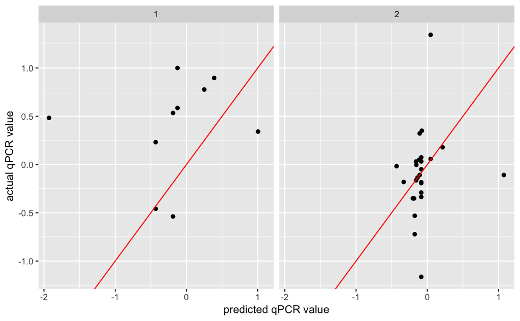

Bayesian Optimization Scenario 1. Let’s try to see if the Bayesian Optimization protocol can be used to more efficiently sample the topography space to maximize PCR. Recall that for Bayesian optimization, we only use the weighted sum of Genes4-Genes7 (single objective optimization).

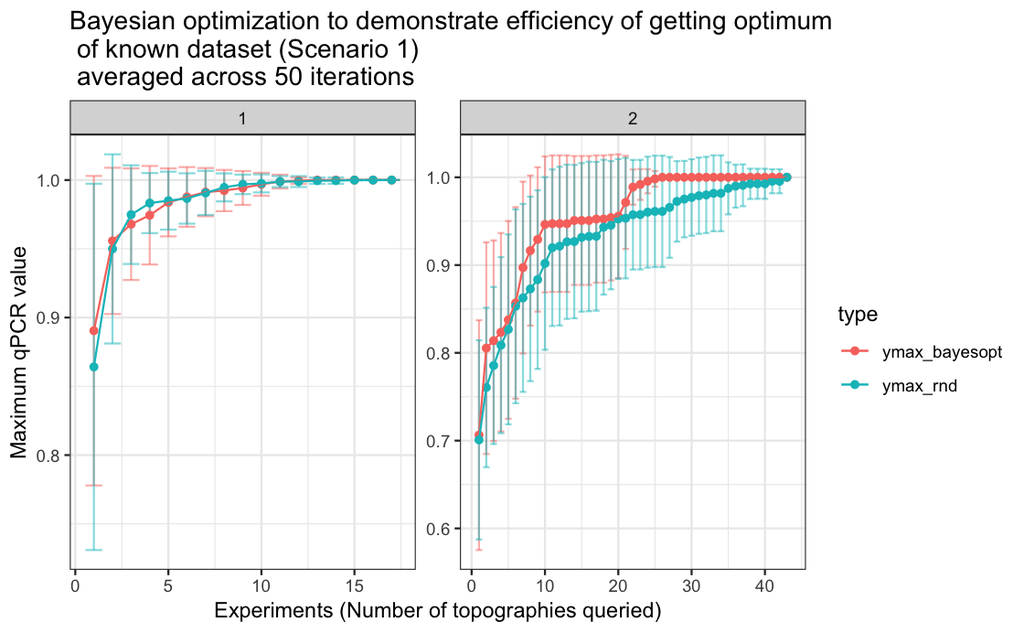

Lets find out how many iterations are needed on average to obtain the maximum using Bayesian optimization and the random search

```r
for (g in 1:2){
   averageDataSubset <- subset(averageData, averageData$geometry == g)
   yMaxIndex<-which(averageDataSubset$mean.value==max(averageDataSubset$mean.value))
   BayesOptMaxIndex <- averageDataSubset[min(yMaxIndex[lapply(yMaxIndex, "%%", 2)!=0]), 1]
   RndMaxIndex <- averageDataSubset[min(yMaxIndex[lapply(yMaxIndex, "%%", 2)==0]), 1]
   print(glue("Max iterations needed by Bayes Opt to get to optimum of geometry {g} is {BayesOptMaxIndex}"))
   print(glue("Max iterations needed by Rnd to get to optimum of geometry {g} is {RndMaxIndex}"))
}
```

```
Max iterations needed by Bayes Opt to get to optimum of geometry 1 is 15
Max iterations needed by Rnd to get to optimum of geometry 1 is 17
Max iterations needed by Bayes Opt to get to optimum of geometry 2 is 26
Max iterations needed by Rnd to get to optimum of geometry 2 is 43
```

```r
geomData_geom1 <- subset(allData, allData$Geometry_Number == 1)
geomData_geom2 <- subset(allData, allData$Geometry_Number == 2)
predictedgeom1_all_s1 <- NULL
predictedgeom2_all_s1 <- NULL

for(num in 1:exp){
   s4Subset_geom1 <- subset(allTopoToPcr_s1, allTopoToPcr_s1$experiment==num & allTopoToPcr_s1$geometry == 1)
   s4Subset_geom2 <- subset(allTopoToPcr_s1, allTopoToPcr_s1$experiment==num & allTopoToPcr_s1$geometry == 2)
   index_geom1 <- min(which(s4Subset_geom1$ymax_bayesopt == max(s4Subset_geom1$ymax_bayesopt)))
   index_geom2 <- min(which(s4Subset_geom2$ymax_bayesopt == max(s4Subset_geom2$ymax_bayesopt)))
   gridIndx_geom1 <- s4Subset_geom1[index_geom1,3]
   gridIndx_geom2 <- s4Subset_geom2[index_geom2,3]
   topo_geom1 <- geomData_geom1[gridIndx_geom1[[1]],]
   topo_geom2 <- geomData_geom2[gridIndx_geom2[[1]],]
   rescale_topo_geom1 <- bind_cols(Disorder = topo_geom1[,7]*335.19+200, Diameter = topo_geom1[,8]*736.36+811.11)
   rescale_topo_geom2 <- bind_cols(Disorder = topo_geom2[,7]*221.81+129.09, Diameter = topo_geom2[,8]*582.62+390.91)
   predictedgeom1_all_s1 <- rbind(predictedgeom1_all_s1, rescale_topo_geom1)
   predictedgeom2_all_s1 <- rbind(predictedgeom2_all_s1, rescale_topo_geom2)
}

print(glue("For HEX geometry, max topography have disorder {unique(predictedgeom1_all_s1[[1]])} and diameter {unique(predictedgeom1_all_s1[[2]])}"))
```

```
For HEX geometry, max topography have disorder 0.000538593050009695 and diameter 999.99955545292
```

```r
   print(glue("For SQ geometry, max topography have disorder {unique(predictedgeom2_all_s1[[1]])} and diameter {unique(predictedgeom2_all_s1[[2]])}"))
```

```
For SQ geometry, max topography have disorder -0.00159361646001344 and diameter 999.99709356544
```

Next, we use Gaussian Process (GP) regression to create a model that predicts individual PCR values using the topography parameters. GP regression is performed with train and test sets, validation performed using test set.

```
Y4   -0.030349
Y5    0.026592
Y6   -0.006232
Y7    0.029510
dtype: float64
```

```
Y4   -0.014396
Y5   -0.034260
Y6    0.032841
Y7   -0.038241
dtype: float64
```

We plot the results of the Gaussian Process Regression here.

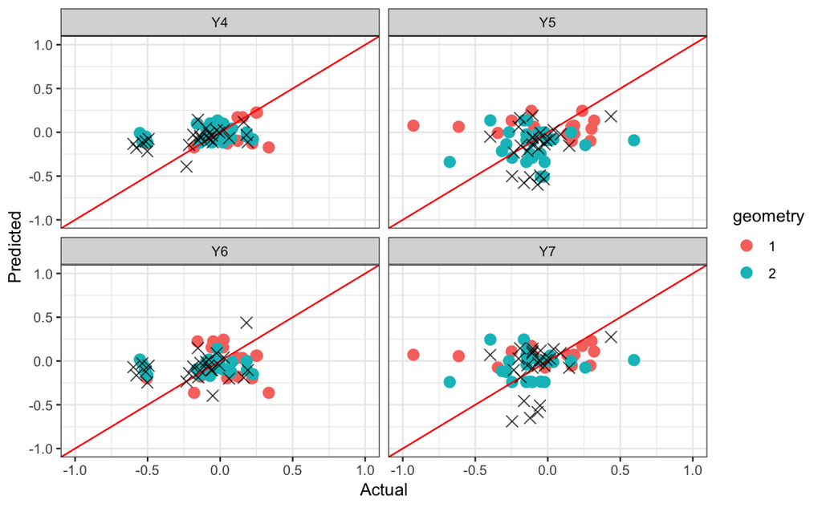

```r
ypredicted_geom_1 <- as.data.frame(py$ypredicted_geom_1)
ypredicted_geom_1$geometry <- "1"
names(ypredicted_geom_1) <- c("Y4", "Y5", "Y6", "Y7", "geometry")

ytrainpred_geom_1 <- as.data.frame(py$ytrain_geom_1)
ytrainpred_geom_1$geometry <- "1"
names(ytrainpred_geom_1) <- c("Y4", "Y5", "Y6", "Y7", "geometry")

ypredicted_geom_2 <- as.data.frame(py$ypredicted_geom_2)
ypredicted_geom_2$geometry <- "2"
names(ypredicted_geom_2) <- c("Y4", "Y5", "Y6", "Y7", "geometry")

ytrainpred_geom_2 <- as.data.frame(py$ytrain_geom_2)
ytrainpred_geom_2$geometry <- "1"
names(ytrainpred_geom_2) <- c("Y4", "Y5", "Y6", "Y7", "geometry")

yPredictedAll<-as.data.frame(bind_rows(ypredicted_geom_1, ypredicted_geom_2))

yTrainAll<-as.data.frame(bind_rows(ytrainpred_geom_1, ytrainpred_geom_2))

y_test_geom1 <- as.data.frame(py$y_test_geom1)
y_test_geom1$geometry <- "1"
names(y_test_geom1) <- c("Y4", "Y5", "Y6", "Y7", "geometry")
y_test_geom2 <- as.data.frame(py$y_test_geom2)
y_test_geom2$geometry <- "2"
names(y_test_geom2) <- c("Y4", "Y5", "Y6", "Y7", "geometry")
yTestAll<-as.data.frame(bind_rows(y_test_geom1, y_test_geom2))

yPredAllMelt <- as.data.frame(melt(yPredictedAll, value.name = "Predicted", variable.name = "Gene", id.vars=c("geometry")))
yTestAllMelt <- as.data.frame(melt(yTestAll[,2:3], value.name = "Actual", variable.name = "Gene2"))
yAllTestDataMelt <- cbind(yPredAllMelt, yTestAllMelt)

y_train_geom1 <- as.data.frame(py$y_train_geom1)
y_train_geom1$geometry <- "1"
names(y_train_geom1) <- c("Y4", "Y5", "Y6", "Y7", "geometry")
y_train_geom2 <- as.data.frame(py$y_train_geom2)
y_train_geom2$geometry <- "2"
names(y_train_geom2) <- c("Y4", "Y5", "Y6", "Y7", "geometry")
yTrainAll<-as.data.frame(bind_rows(y_train_geom2, y_train_geom2))

yTrainPredAllMelt <- as.data.frame(melt(yTrainAll, value.name = "Predicted", variable.name = "Gene", id.vars=c("geometry")))
yTrainAllMelt <- as.data.frame(melt(yTrainAll[,2:3], value.name = "Actual", variable.name = "Gene2"))
yAllTrainDataMelt <- cbind(yTrainPredAllMelt, yTrainAllMelt)


byActual <- yAllTrainDataMelt %>% group_by(Actual, Gene, geometry)

summaryTrainData <- byActual %>%
 summarise(
  count = n(),
  Predicted = median(Predicted, na.rm = TRUE),
  sd = sd(Predicted, na.rm = TRUE))


ggplot(yAllTestDataMelt, aes(x=Actual, y=Predicted, color = geometry)) +
   geom_point(size=3) +
   geom_abline(color="red") +
   geom_point(data=yAllTrainDataMelt, fun.y="median", col="black", alpha=0.5, shape=4, size=3) +
   coord_cartesian(xlim=c(-1,1), ylim=c(-1,1)) +
   facet_wrap(~Gene) + theme_bw()
```

Accuracy of the GP models using the test set.

```r
print(paste0("Gene4 MAE using GP regression is (original data):", MAE(yTestAll$Y4, yPredictedAll$Y4)))
```

```
[1] "Gene4 MAE using GP regression is (original data):0.129414846662846"
```

```r
print(paste0("Gene5 MAE using GP regression is (original data):", MAE(yTestAll$Y5, yPredictedAll$Y5)))
```

```
[1] "Gene5 MAE using GP regression is (original data):0.165986138225469"
```

```r
print(paste0("Gene6 MAE using GP regression is (original data):", MAE(yTestAll$Y6, yPredictedAll$Y6)))
```

```
[1] "Gene6 MAE using GP regression is (original data):0.159809797654891"
```

```r
print(paste0("Gene7 MAE using GP regression is (original data):", MAE(yTestAll$Y7, yPredictedAll$Y7)))
```

```
[1] "Gene7 MAE using GP regression is (original data):0.21461634407585"
```

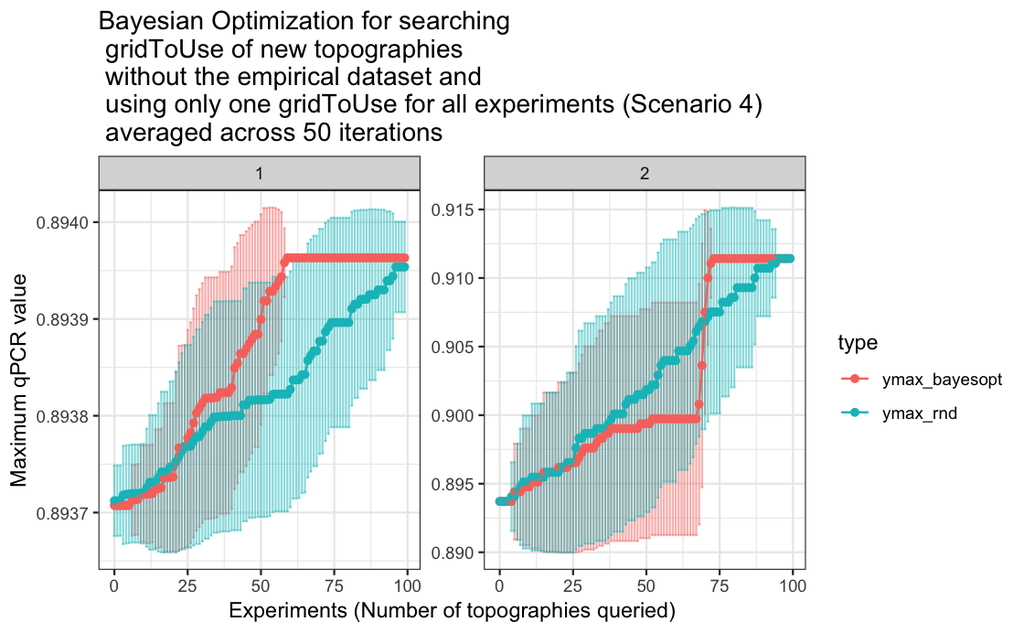

How many experiments needed on average to obtain the osteogenic maximum?

```r
for (g in 1:2){
   averageDataSubset_s4 <- subset(averageData_s4, averageData_s4$geometry == g)
   yMaxIndex<-which(averageDataSubset_s4$mean.value==max(averageDataSubset_s4$mean.value))
   BayesOptMaxIndex <- averageDataSubset_s4[min(yMaxIndex[lapply(yMaxIndex, "%%", 2)!=0]), 1]
   RndMaxIndex <- averageDataSubset_s4[min(yMaxIndex[lapply(yMaxIndex, "%%", 2)==0]), 1]
   print(glue("Average Min iterations needed by Bayes Opt to get to optimum of geometry {g} is {BayesOptMaxIndex}"))
   print(glue("Average Min iterations needed by Rnd to get to optimum of geometry {g} is {RndMaxIndex}"))
}
```

```
Average Min iterations needed by Bayes Opt to get to optimum of geometry 1 is 59
Average Min iterations needed by Rnd to get to optimum of geometry 1 is NA
Average Min iterations needed by Bayes Opt to get to optimum of geometry 2 is 73
Average Min iterations needed by Rnd to get to optimum of geometry 2 is 95
```

What are the disorder and diamter of the topographies that maximize osteogenesis?

```r
predictedgeom1_all_s4 <- NULL
predictedgeom2_all_s4 <- NULL

for(num in 1:exp){
   s4Subset_geom1 <- subset(allTopoToPcrGridMaxData_s4_geom1, allTopoToPcrGridMaxData_s4_geom1$experiment==num)
   s4Subset_geom2 <- subset(allTopoToPcrGridMaxData_s4_geom2, allTopoToPcrGridMaxData_s4_geom2$experiment==num)
   index_geom1 <- min(which(s4Subset_geom1$ymax_bayesopt == max(s4Subset_geom1$ymax_bayesopt)))-1
   index_geom2 <- min(which(s4Subset_geom2$ymax_bayesopt == max(s4Subset_geom2$ymax_bayesopt)))-1
   gridIndx_geom1 <- s4Subset_geom1[index_geom1,5]
   gridIndx_geom2 <- s4Subset_geom2[index_geom2,5]
   topo_geom1 <- gridToUse[gridIndx_geom1,]
   topo_geom2 <- gridToUse[gridIndx_geom2,]
   rescale_topo_geom1 <- bind_cols(Disorder = topo_geom1[1]*335.19+200, Diameter = topo_geom1[2]*736.36+811.11)
   rescale_topo_geom2 <- bind_cols(Disorder = topo_geom2[1]*221.81+129.09, Diameter = topo_geom2[2]*582.62+390.91)
  predictedgeom1_all_s4 <- rbind(predictedgeom1_all_s4, rescale_topo_geom1)
  predictedgeom2_all_s4 <- rbind(predictedgeom2_all_s4, rescale_topo_geom2)
}

print(glue("For HEX geometry, max topography have disorder {unique(predictedgeom1_all_s4[[1]])} and diameter {unique(predictedgeom1_all_s4[[2]])}"))
```

```
For HEX geometry, max topography have disorder 561.447818495712 and diameter 2206.93134624941
```

```r
   print(glue("For SQ geometry, max topography have disorder {unique(predictedgeom2_all_s4[[1]])} and diameter {unique(predictedgeom2_all_s4[[2]])}"))
```

```
For SQ geometry, max topography have disorder 581.780063140498 and diameter 987.452200561408
```